# Midterm

As the plot shows the seasonality is a big factor affects the candy market.

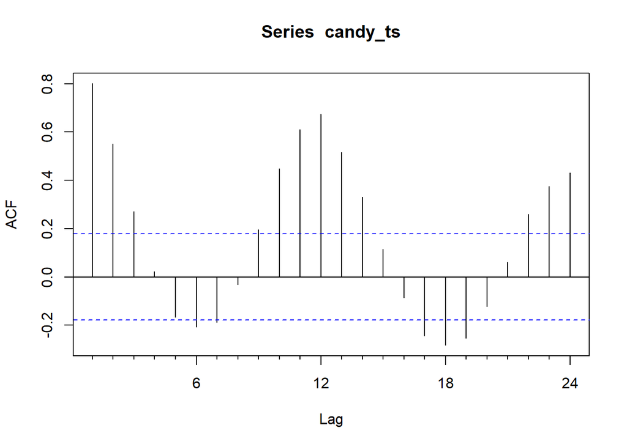

```r
stl_decomp <- stl(candy_ts,s.window ="periodic")
Acf(candy_ts)
```

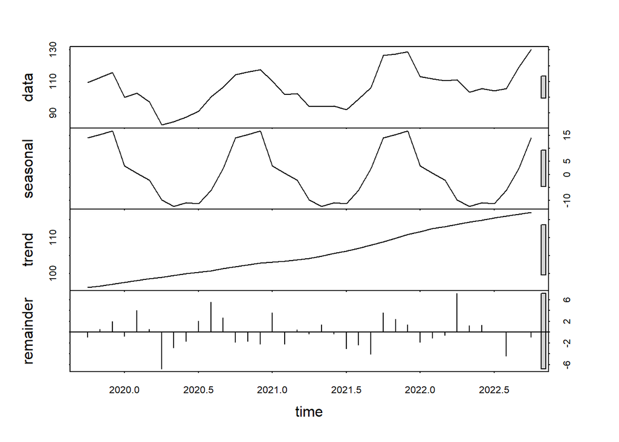

```r
candy_ts<-window(candy_ts, start=c(2019, 10), end=c(2022, 10))
  stl_decomp <- stl(candy_ts,s.window ="periodic")
plot(stl_decomp)
```

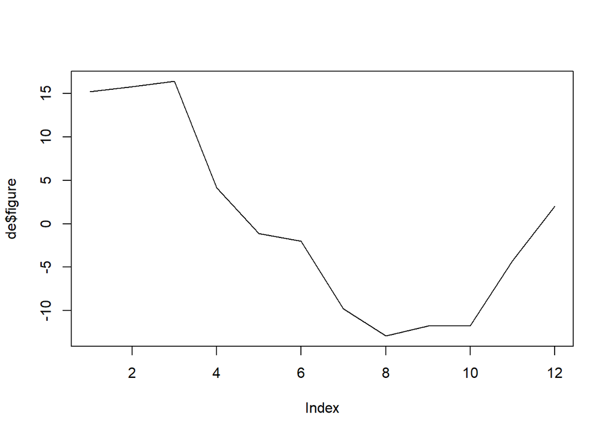

```r
de<-decompose(candy_ts)
plot(de$figure, type="l")
```

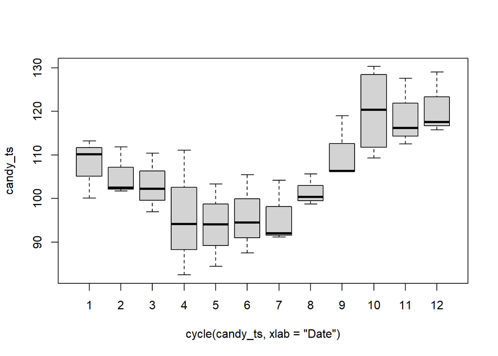

```r
boxplot(candy_ts~cycle(candy_ts, xlab="Date"))
```

```r
##

##
seasadj(stl_decomp)
```

```
##            Jan       Feb       Mar       Apr       May       Jun       Jul
## 2019
## 2020  96.78144 102.10590  99.07019  92.27158  96.62169  98.33354 102.48744
## 2021 106.86234 101.33200 104.33199 103.91818 106.30279 105.26084 103.32494
## 2022 109.86104 111.41460 112.55529 120.87268 115.52499 116.24214 115.52064
##            Aug       Sep       Oct       Nov       Dec
## 2019                      95.20639  97.14421  99.03242
## 2020 106.38874 104.02168 100.11859 100.82361 100.80942
## 2021 104.77714 103.94108 112.48559 112.24291 112.31532
## 2022 111.66364 116.72828 116.19969
```

```r
attributes(seasadj(stl_decomp))
```

```
## $tsp
## [1] 2019.75 2022.75   12.00
##
## $class
## [1] "ts"
```

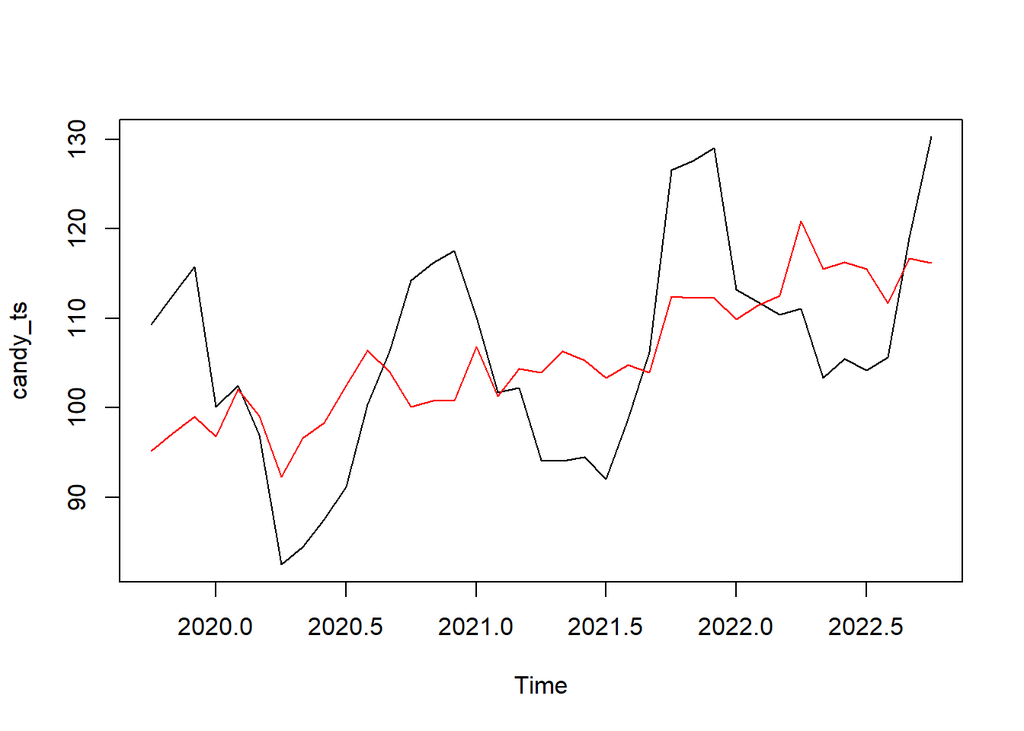

```r
plot(candy_ts)
lines(seasadj(stl_decomp), col="Red")
```

####Naive 1.output figure below 2.1 The plot did not show a clear pattern.And around 0. 2 The histogram shows that a bit left skewed distribution basically normal distributed. 3.The plot shows that the residual are not correlated to fitted value, since there is no pattern. But the residual greater than 0 a bit more 4 actual value vs residual shows that a patter of residual goes with values instead of random. 5.Plot shows a seasonality at lag of 12. 3. ME RMSE MAE MPE MAPE MASE Training set 0.5831472 7.58967 5.565397 0.2378962 5.25893 0.7455992 ACF1 Training set 0.254362 4. 5.The RMSE shows that on average the forecast value is 7.58967 away from actual.

```r
candy_ts_naive <- naive(candy_ts)
attributes(candy_ts_naive)
```

```
## $names
##  [1] "method"    "model"     "lambda"    "x"         "fitted"    "residuals"
##  [7] "series"    "mean"      "level"     "lower"     "upper"
##
## $class
## [1] "forecast"
```

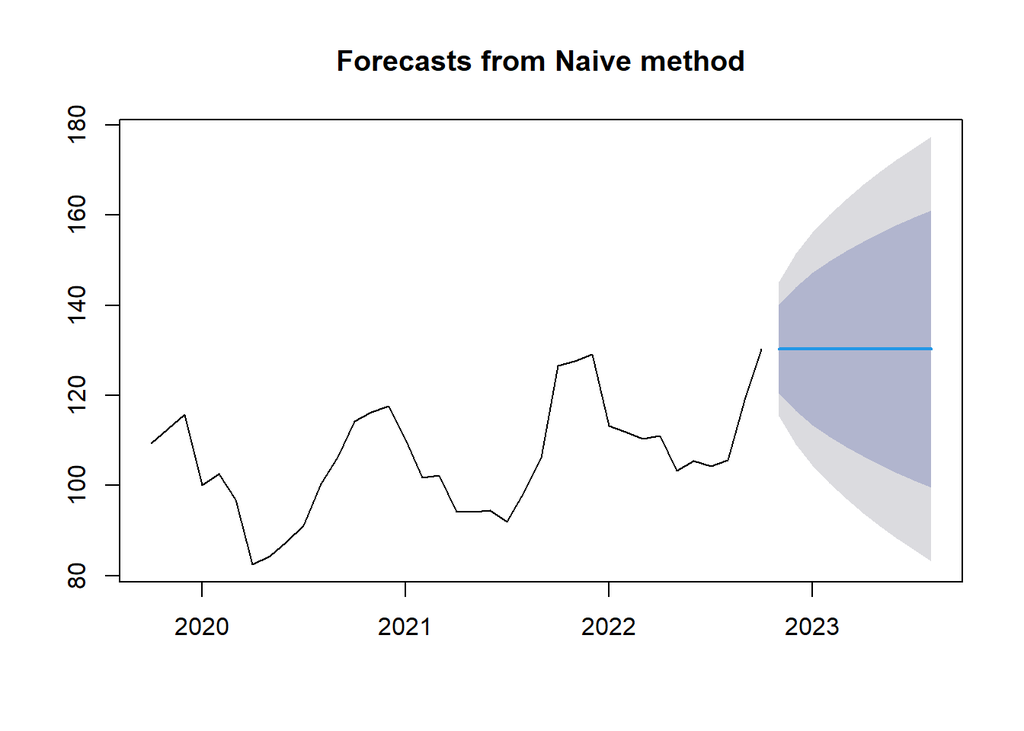

```r
plot(candy_ts_naive)
```

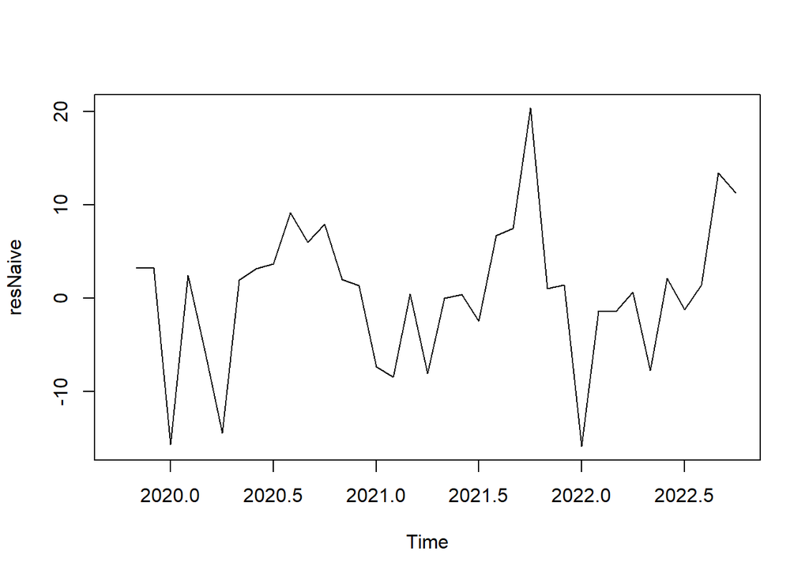

```r
resNaive <- residuals(candy_ts_naive)

plot(resNaive)
```

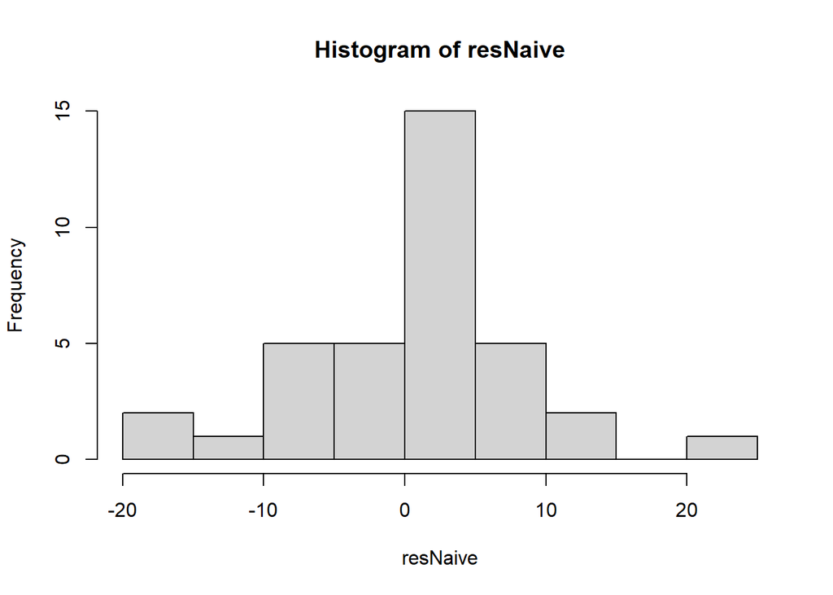

```r
hist(resNaive)
```

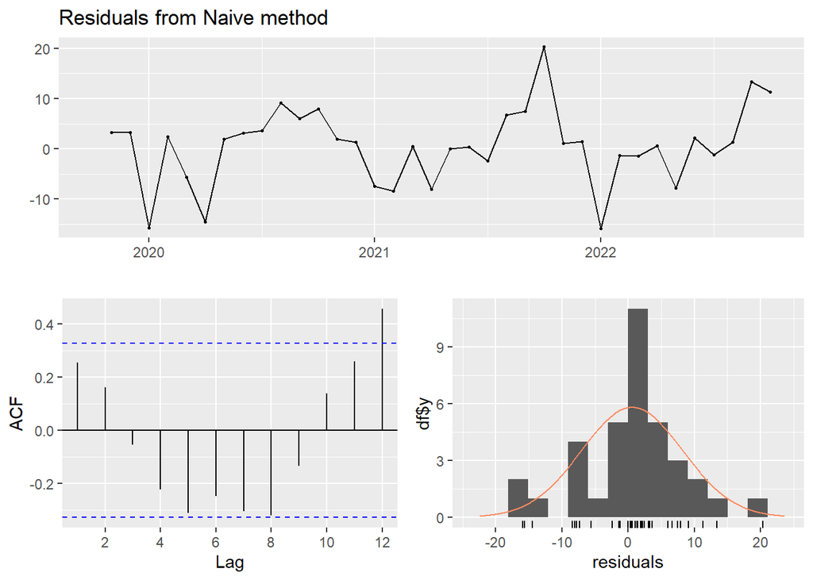

```
##
##  Ljung-Box test
##
## data:  Residuals from Naive method
## Q* = 17.166, df = 7, p-value = 0.01635
##
## Model df: 0.   Total lags used: 7
```

```r
checkresiduals(candy_ts_naive)
```

```r
resNaive
```

```
##           Jan      Feb      Mar      Apr      May      Jun      Jul      Aug
## 2019
## 2020 -15.6779   2.4265  -5.5885 -14.4635   1.9378   3.1256   3.6605   9.1401
## 2021  -7.3740  -8.4283   0.4472  -8.0787  -0.0277   0.3718  -2.4293   6.6910
## 2022 -15.8812  -1.3444  -1.4121   0.6525  -7.7600   2.1309  -1.2149   1.3818
##           Sep      Oct      Nov      Dec
## 2019                NA   3.2307   3.2543
## 2020   5.9678   7.8988   1.9979   1.3519
## 2021   7.4988  20.3464   1.0502   1.4385
## 2022  13.3995  11.2733
```

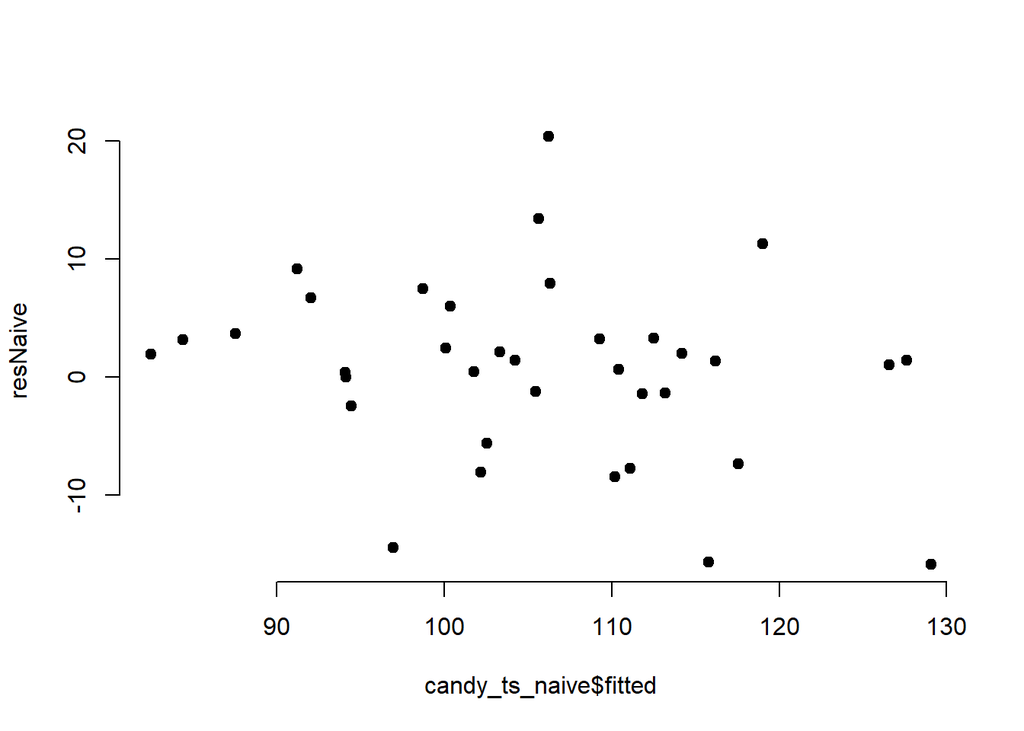

```r
#3
plot.ts(candy_ts_naive$fitted, resNaive,
     pch = 19, frame = FALSE,xy.labels=FALSE)
```

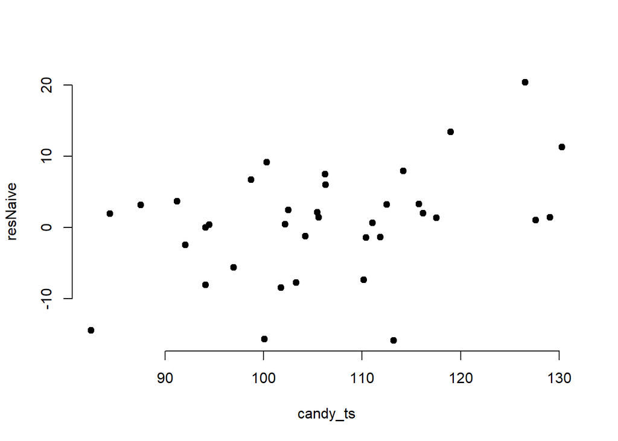

```r
#4
plot.ts(candy_ts, resNaive,
     pch = 19, frame = FALSE,xy.labels=FALSE)
```

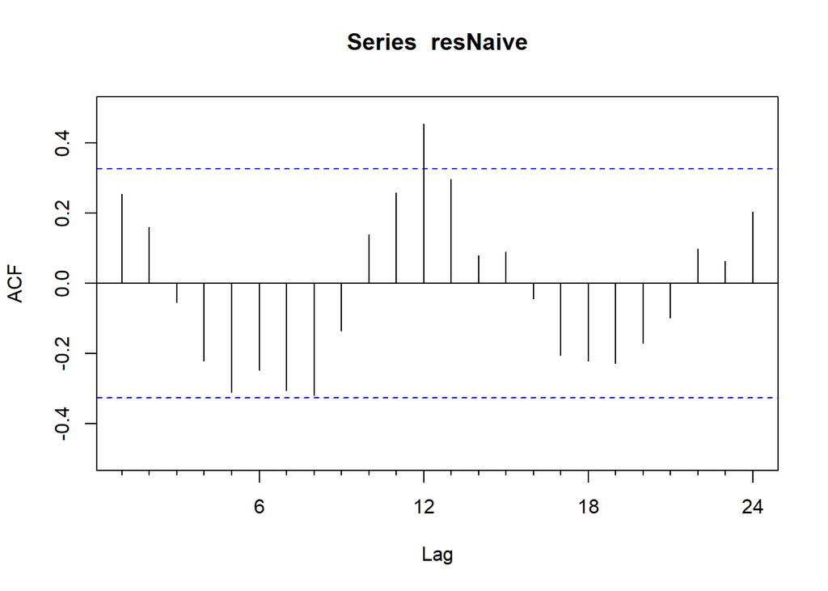

```r
#5
Acf(resNaive)
```

```r
#6
accuracy(candy_ts_naive)
```

```
##                     ME    RMSE      MAE       MPE    MAPE      MASE     ACF1
## Training set 0.5831472 7.58967 5.565397 0.2378962 5.25893 0.7455992 0.254362
```

```r
#7
naive(candy_ts,12)
```

```
##          Point Forecast     Lo 80    Hi 80     Lo 95    Hi 95
## Nov 2022       130.2894 120.56285 140.0160 115.41392 145.1649
## Dec 2022       130.2894 116.53398 144.0448 109.25229 151.3265
## Jan 2023       130.2894 113.44251 147.1363 104.52431 156.0545
## Feb 2023       130.2894 110.83629 149.7425 100.53844 160.0404
## Mar 2023       130.2894 108.54016 152.0386  97.02681 163.5520
## Apr 2023       130.2894 106.46431 154.1145  93.85206 166.7267
## May 2023       130.2894 104.55536 156.0234  90.93258 169.6462
## Jun 2023       130.2894 102.77855 157.8002  88.21519 172.3636
## Jul 2023       130.2894 101.10974 159.4691  85.66296 174.9158
## Aug 2023       130.2894  99.53134 161.0475  83.24900 177.3298
## Sep 2023       130.2894  98.03007 162.5487  80.95301 179.6258
## Oct 2023       130.2894  96.59563 163.9832  78.75922 181.8196
```

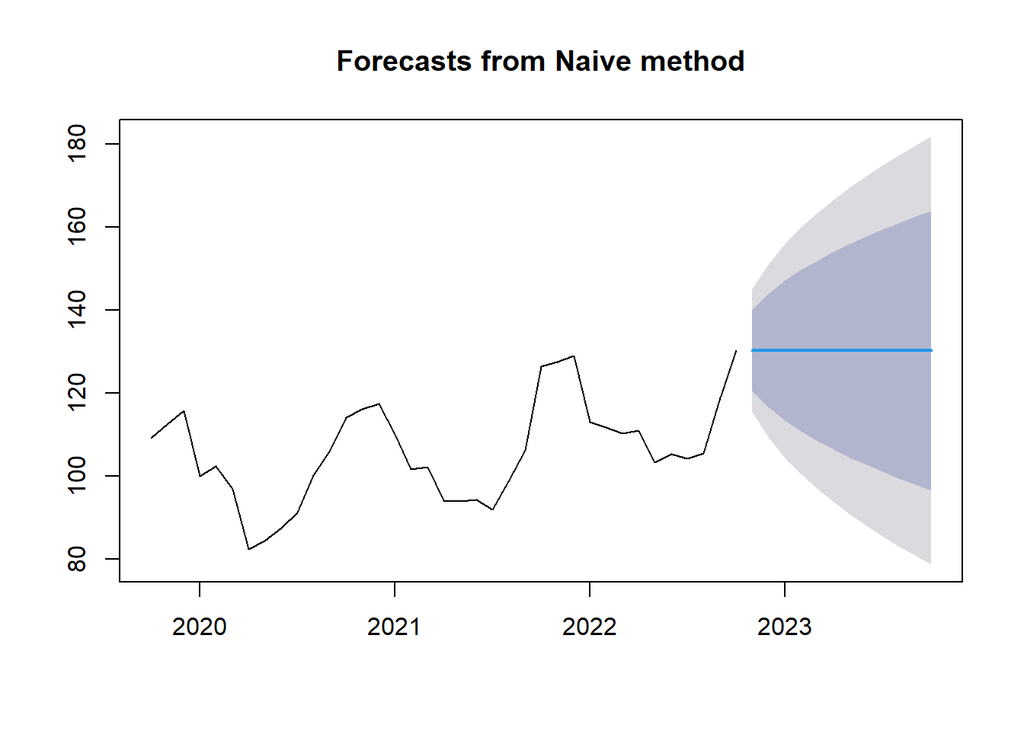

```r
plot(naive(candy_ts,12))
```

####Simple Moving Averages

The curve become smoother.

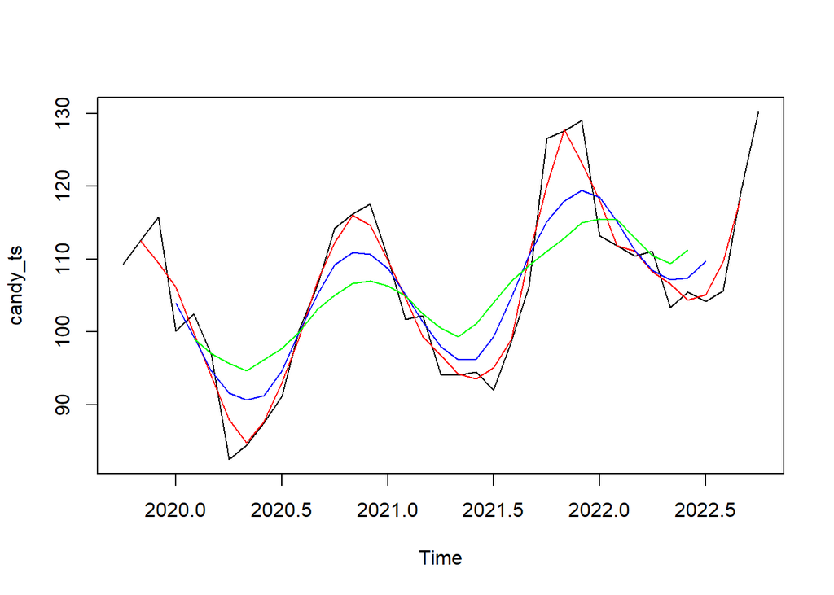

```r
plot(candy_ts)
MA3_forecast <- ma(candy_ts,order=3)
MA6_forecast <- ma(candy_ts,order=6)
MA9_forecast <- ma(candy_ts,order=9)
lines(MA3_forecast,col="Red")
lines(MA6_forecast,col="Blue")
lines(MA9_forecast,col="Green")
```

```r
forecast(MA9_forecast,12)
```

```
##          Point Forecast     Lo 80    Hi 80     Lo 95    Hi 95
## Jul 2022       112.9446 110.99409 114.8950 109.96158 115.9276
## Aug 2022       114.7715 110.54372 118.9993 108.30565 121.2374
## Sep 2022       116.5985 109.53853 123.6584 105.80122 127.3958
## Oct 2022       118.4255 108.06773 128.7832 102.58468 134.2662
## Nov 2022       120.2524 106.18024 134.3246  98.73088 141.7740
## Dec 2022       122.0794 103.90839 140.2504  94.28925 149.8695
## Jan 2023       123.9063 101.27528 146.5374  89.29511 158.5176
## Feb 2023       125.7333  98.29809 153.1685  83.77476 167.6918
## Mar 2023       127.5603  94.98989 160.1306  77.74817 177.3724
## Apr 2023       129.3872  91.36070 167.4137  71.23067 187.5438
## May 2023       131.2142  87.41817 175.0102  64.23397 198.1944
## Jun 2023       133.0411  83.16807 182.9142  56.76686 209.3154
```

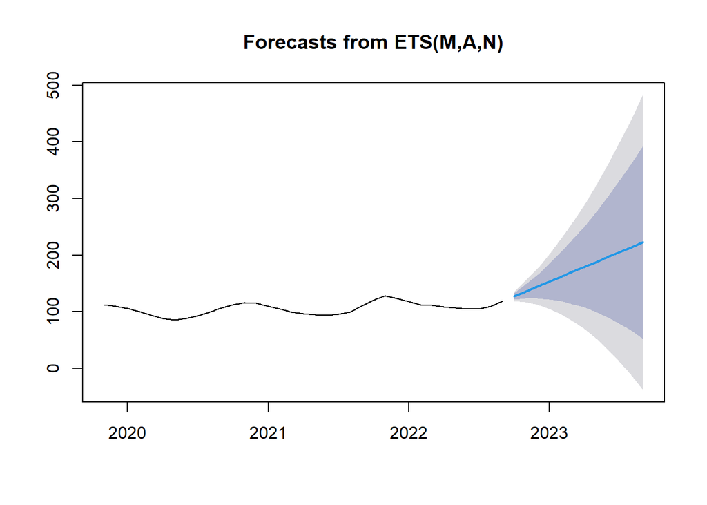

```r
plot(forecast(MA3_forecast,12))
```

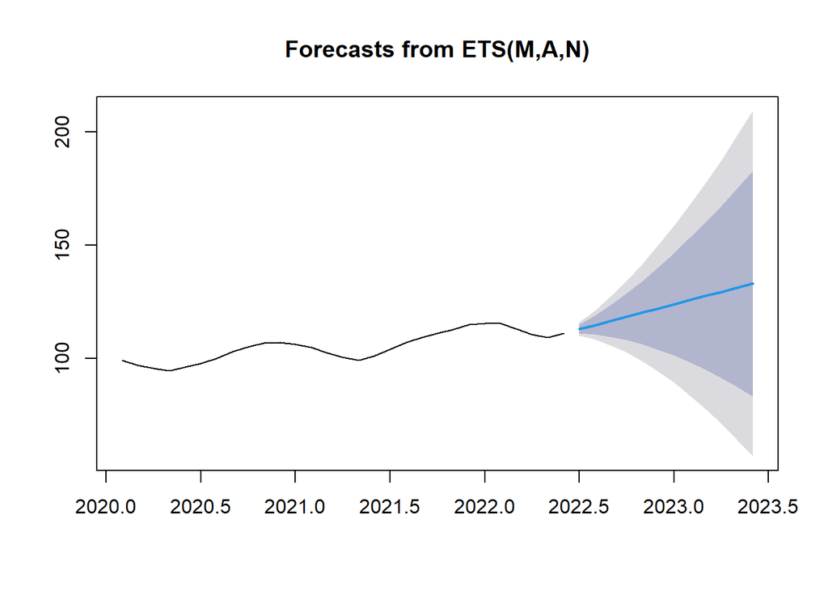

```r
plot(forecast(MA9_forecast,12))
```

```r
accuracy(forecast(MA9_forecast,12))
```

```
##                     ME     RMSE       MAE       MPE      MAPE      MASE
## Training set 0.1146388 1.298365 0.9835448 0.1336029 0.9342238 0.1333998
##                   ACF1
## Training set 0.3838434
```

####Simple Smoothing

1. a =0.9999, after simple smoothing the Value of smoothing parameter for the level indicated that the simple smoothing is more like a naive model l = 109.2924. the initial state value. sigma: 7.6975 2.1 The plot show a clear patter of random. 2 The histogram shows that left skewed distribution. 3.The plot shows that the residual are not correlated to fitted value, since there is no pattern. But the residual greater than 0 a bit more 4 actual value vs residual shows that a patter of residual goes with values instead of random. 5.Plot shows a seasonality at lag of 12.

   Training set 0.5675138 7.486596 5.41525 0.2315472 5.117019 0.7254839 0.2535938
3. 5.The RMSE shows that on average the forecast value is 7.486596 away from actual. And the model totally fails to fit the seasonality.

```r
sesNJ <- ses(candy_ts,h=9)

sesNJ
```

```
##          Point Forecast    Lo 80    Hi 80     Lo 95    Hi 95
## Nov 2022       130.2883 120.4235 140.1531 115.20140 145.3751
## Dec 2022       130.2883 116.3381 144.2385 108.95328 151.6233
## Jan 2023       130.2883 113.2031 147.3734 104.15878 156.4178
## Feb 2023       130.2883 110.5602 150.0163 100.11678 160.4598
## Mar 2023       130.2883 108.2317 152.3448  96.55569 164.0209
## Apr 2023       130.2883 106.1266 154.4499  93.33620 167.2403
## May 2023       130.2883 104.1908 156.3858  90.37557 170.2010
## Jun 2023       130.2883 102.3889 158.1876  87.61988 172.9567
## Jul 2023       130.2883 100.6966 159.8800  85.03167 175.5449
```

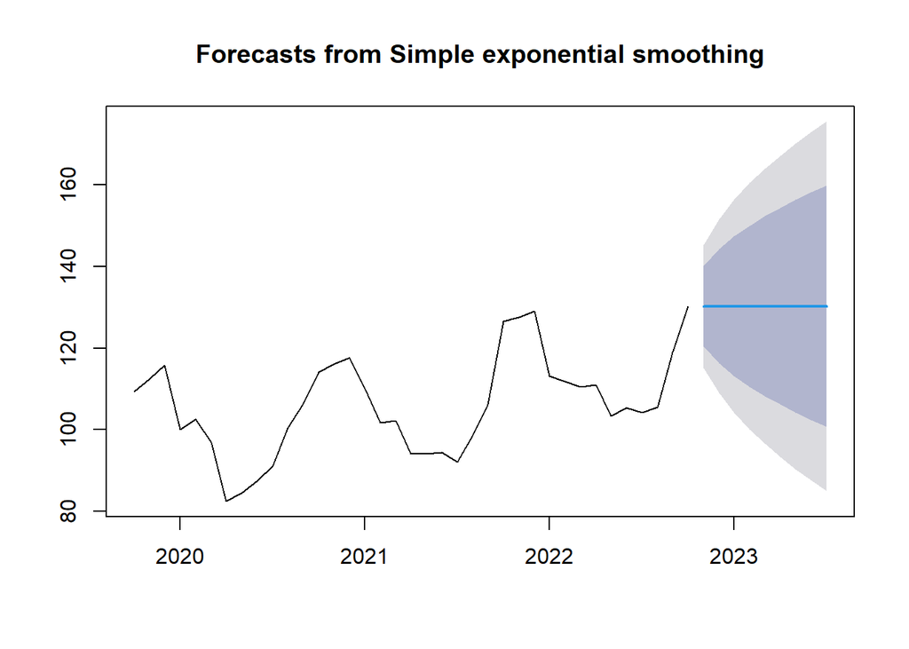

```r
plot(sesNJ)
```

```r
attributes(sesNJ)
```

```
## $names
##  [1] "model"     "mean"      "level"     "x"         "upper"     "lower"
##  [7] "fitted"    "method"    "series"    "residuals"
##
## $class
## [1] "forecast"
```

```r
sesNJ$model
```

```
## Simple exponential smoothing
##
## Call:
##  ses(y = candy_ts, h = 9)
##
##   Smoothing parameters:
##     alpha = 0.9999
##
##   Initial states:
##     l = 109.2924
##
##   sigma:  7.6975
##
##      AIC     AICc      BIC
## 288.5744 289.3017 293.4072
```

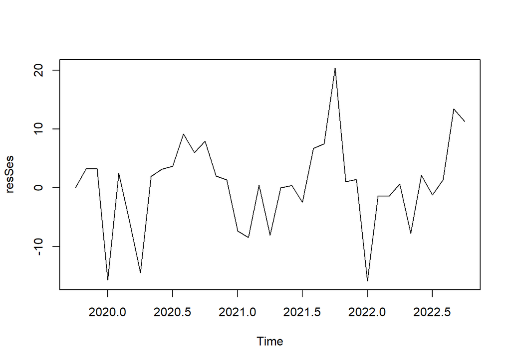

```r
resSes <-sesNJ$residuals
plot(resSes)
```

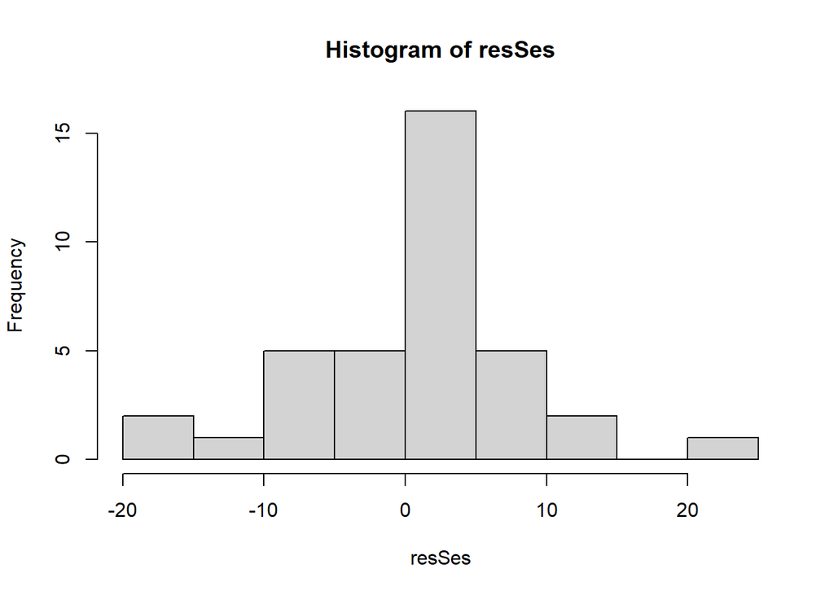

```r
hist(resSes)
```

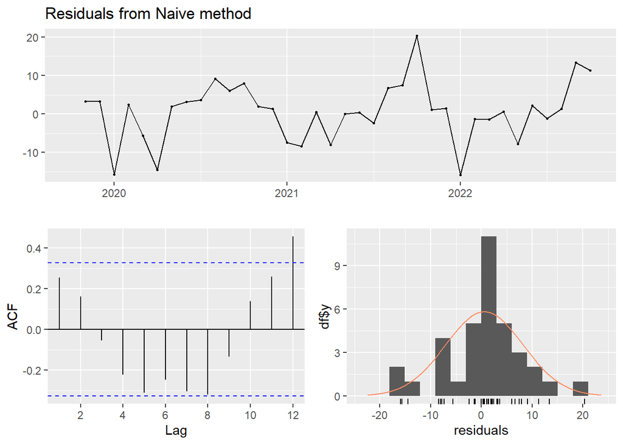

```
##
##  Ljung-Box test
##
## data:  Residuals from Naive method
## Q* = 17.166, df = 7, p-value = 0.01635
##
## Model df: 0.   Total lags used: 7
```

```r
checkresiduals(candy_ts_naive)
```

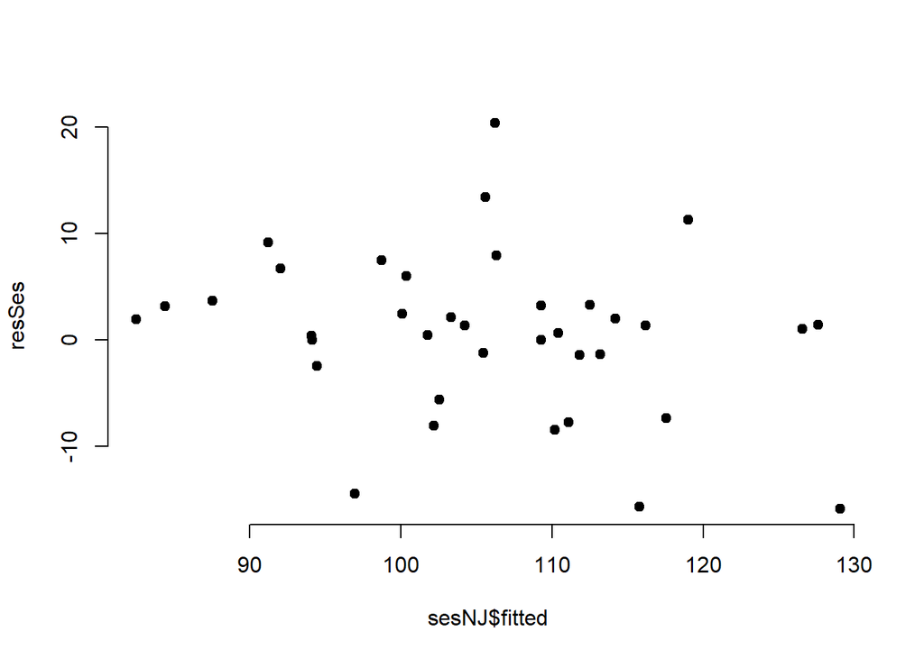

```r
plot.ts(sesNJ$fitted, resSes,
     pch = 19, frame = FALSE,xy.labels=FALSE)
```

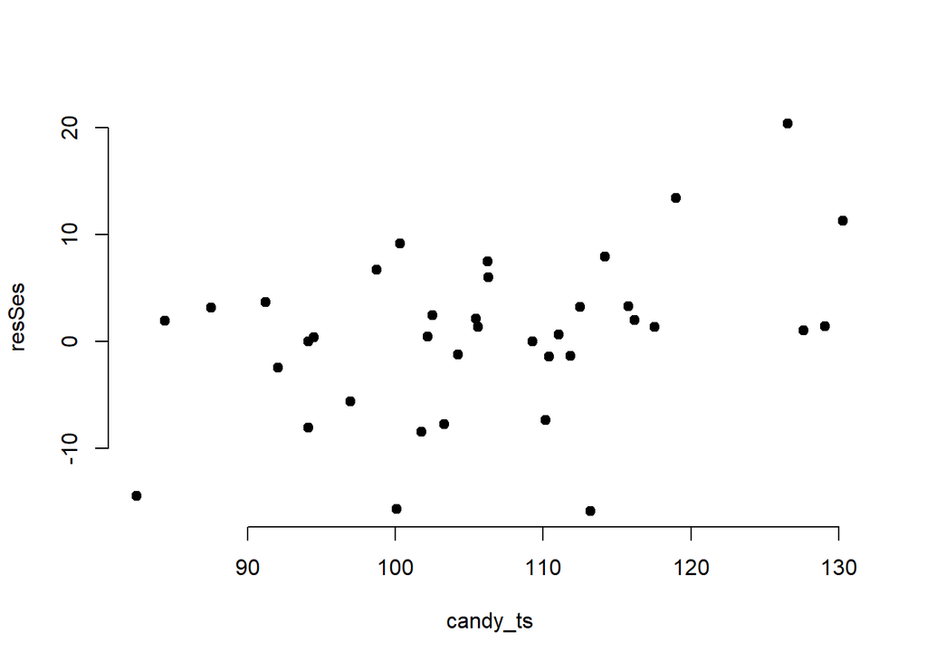

```r
plot.ts(candy_ts, resSes,
     pch = 19, frame = FALSE,xy.labels=FALSE)
```

```r
accuracy(sesNJ)
```

```
##                     ME     RMSE     MAE       MPE     MAPE      MASE      ACF1
## Training set 0.5675138 7.486596 5.41525 0.2315472 5.117019 0.7254839 0.2535938
```

```r
forecast(sesNJ,12)
```

```
##          Point Forecast    Lo 80    Hi 80     Lo 95    Hi 95
## Nov 2022       130.2883 120.4235 140.1531 115.20140 145.3751
## Dec 2022       130.2883 116.3381 144.2385 108.95328 151.6233
## Jan 2023       130.2883 113.2031 147.3734 104.15878 156.4178
## Feb 2023       130.2883 110.5602 150.0163 100.11678 160.4598
## Mar 2023       130.2883 108.2317 152.3448  96.55569 164.0209
## Apr 2023       130.2883 106.1266 154.4499  93.33620 167.2403
## May 2023       130.2883 104.1908 156.3858  90.37557 170.2010
## Jun 2023       130.2883 102.3889 158.1876  87.61988 172.9567
## Jul 2023       130.2883 100.6966 159.8800  85.03167 175.5449
```